# FigureYa293machineLearningV2

**Author(s)**: Guoqi Li; Yasi Zhang  
**Reviewer(s)**: Ying Ge  
**Date**: 2025-05-20

# 需求描述

# Demand description

这个文章里比较不同的模型放在一个图，以及比较不同的算法放在一个图。

In this article, different models are compared in one graph, and different algorithms are compared in another graph.

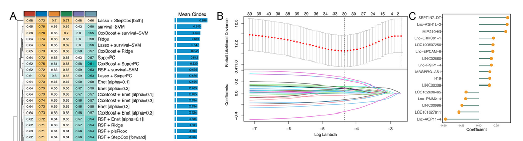

出自https://www.nature.com/articles/s41467-022-28421-6

图2 通过基于机器学习的整合流程，开发并验证了一种共识性IRLS模型。 A 在LOOCV框架下构建了共计101种预测模型，并计算了各模型在所有验证数据集中的C指数。 B 在TCGA-CRC队列（n = 584）中，当偏似然偏差达到最小值时确定最优λ值，并进一步生成最具预后价值基因的Lasso系数。数据以均值±95%置信区间[CI]表示。 C 逐步Cox回归最终获得的16个lncRNA系数。 D–K 基于IRLS的TCGA-CRC患者总生存期（OS）Kaplan-Meier曲线（对数秩检验：P = 9.16e−19）。

Source: https://www.nature.com/articles/s41467-022-28421-6

Fig. 2 A consensus IRLS was developed and validated via the machine learning-based integrative procedure. A A total of 101 kinds of prediction models via LOOCV framework and further calculated the C-index of each model across all validation datasets. B In the TCGA-CRC cohort (n = 584), the determination of the optimal λ was obtained when the partial likelihood deviance reached the minimum value, and further generated Lasso coefficients of the most useful prognostic genes. Data are presented as mean ± 95% confidence interval [CI]. C Coefficients of 16 lncRNAs finally obtained in stepwise. Cox regression. D–K Kaplan–Meier curves of OS according to the IRLS in TCGA-CRC (log-rank test: P = 9.16e−19).

# 应用场景

# Application scenarios

基于这10种算法的组合去构建模型，会受到输入数据集的基因数目和质量的影响。

因此，基于不同的基因，有些模型可能得不到特征而出现报错的现象，这属于正常现象。

最后的result都会有结果，但是得到结果会有变化，以及有些模型（指单一模型）或模型组合（指组合模型）预测效能的C指数为0.5，这些模型都是未得到结果的模型（根本原因是输入数据中基因的问题），所以可以调整输入数据的基因来获取更多有结果的模型组合结果。

例文当中有些Figure的画法可参考我们之前众筹过的FigureYa：

- Figure 1，FigureYa69cancerSubtype、FigureYa71ssGSEA、FigureYa55panCancer_violin、FigureYa15WGCNA、FigureYa170ImmuLncRNA
- Figure 2，FigureYa293machineLearning、FigureYa31lasso、FigureYa35batch_bestSeparation
- Figure 3，FigureYa189timeCindex、FigureYa220repeatedLasso
- Figure 5，FigureYa90subgroup
- Figure 6，FigureYa105GDSC
- Figure 7，FigureYa71ssGSEA、FigureYa152DouleCorPlot

The performance of models built using these 10 algorithms in combination is influenced by the number and quality of genes in the input dataset.

Therefore, depending on the genes used, some models may fail to extract features and return errors—this is a normal occurrence.

All final results will be generated, but the outcomes may vary. Additionally, some models (single models) or model combinations (ensemble models) may yield a C-index of 0.5, indicating that they failed to produce meaningful results (primarily due to issues with the input gene data). To obtain more valid model combinations, adjusting the input gene set may help.

For reference on figure design, you may consult our previously crowdsourced FigureYa:

- Figure 1，FigureYa69cancerSubtype、FigureYa71ssGSEA、FigureYa55panCancer_violin、FigureYa15WGCNA、FigureYa170ImmuLncRNA
- Figure 2，FigureYa293machineLearning、FigureYa31lasso、FigureYa35batch_bestSeparation
- Figure 3，FigureYa189timeCindex、FigureYa220repeatedLasso
- Figure 5，FigureYa90subgroup
- Figure 6，FigureYa105GDSC
- Figure 7，FigureYa71ssGSEA、FigureYa152DouleCorPlotexamples.

# 环境设置

# Environment Setup

使用国内镜像安装包。

Using domestic mirrors for package installation.

```r
options("repos"= c(CRAN="https://mirrors.tuna.tsinghua.edu.cn/CRAN/"))
options(BioC_mirror="http://mirrors.tuna.tsinghua.edu.cn/bioconductor/")
BiocManager::install("mixOmics")
install.packages("plsRcox")
BiocManager::install("survcomp")
install.packages("rlang")
library(devtools)
install_github("binderh/CoxBoost")
```

# 加载包

# Loading packages

```r
library(survival)
library(randomForestSRC)
library(glmnet)
library(plsRcox)
library(superpc)
library(gbm)
library(CoxBoost)
library(survivalsvm)
library(dplyr)
library(tibble)
library(BART)
```

```r
library(miscTools)
library(compareC)
library(ggplot2)
library(ggsci)
library(tidyr)
library(ggbreak)
# 显示英文报错信息
# Show English error messages
Sys.setenv(LANGUAGE = "en")

# 禁止chr转成factor
# Prevent character-to-factor conversion
options(stringsAsFactors = FALSE)
```

# 输入文件

# Input Files

TCGA.txt，GSE57303.txt，GSE62254.txt，数据集。行为样本，第一列为样本名，第二三列为生存时间和生存状态，后面的列均为基因。文件较大，已上传至微云 https://share.weiyun.com/y3qYgKCK

TCGA.txt, GSE57303.txt, GSE62254.txt, datasets. Rows represent samples, with the first column being sample names, the second and third columns being survival time and survival status, and the remaining columns all being genes. The files are large and have been uploaded to Weiyun https://share.weiyun.com/y3qYgKCK

```r
# 加载数据集
# Load datasets
tcga <- read.table("TCGA.txt", header = T,sep = "\t", quote = "", check.names = F)
GSE57303 <- read.table("GSE57303.txt", header = T, sep = "\t", quote = "", check.names = F)
GSE62254 <- read.table("GSE62254.txt", header = T, sep = "\t", quote = "", check.names = F)

# 生成包含三个数据集的列表
# Create a list containing the three datasets
mm <- list(TCGA = tcga,
           GSE57303 = GSE57303, GSE62254 = GSE62254)

# 数据标准化
# Data standardization
mm <- lapply(mm,function(x){
  x[,-c(1:3)] <- scale(x[,-c(1:3)])
  return(x)})

result <- data.frame()

# TCGA作为训练集
# Use TCGA as the training set
est_data <- mm$TCGA

# GEO作为验证集
# Use GEO as the validation set
val_data_list <- mm

pre_var <- colnames(est_data)[-c(1:3)]
est_dd <- est_data[, c('OS.time', 'OS', pre_var)]
val_dd_list <- lapply(val_data_list, function(x){x[, c('OS.time', 'OS', pre_var)]})

# 设置种子数和节点数，其中节点数可以调整
# Set the seed number and node size (node size can be adjusted)
rf_nodesize <- 5
seed <- 123
```

下面开始实现10种方法：

Below starts the implementation of 10 methods:

# 1.RSF

```r
## 1-1.RSF
set.seed(seed)
fit <- rfsrc(Surv(OS.time,OS)~., data = est_dd,
             ntree = 1000, nodesize = rf_nodesize,
             splitrule = 'logrank',
             importance = T,
             proximity = T,
             forest = T,
             seed = seed)
rs <- lapply(val_dd_list, function(x){cbind(x[, 1:2], RS  = predict(fit, newdata = x)$predicted)})
cc <- data.frame(Cindex = sapply(rs, function(x){as.numeric(summary(coxph(Surv(OS.time, OS) ~ RS, x))$concordance[1])})) %>%
  rownames_to_column('ID')
cc$Model <- 'RSF'
result <- rbind(result, cc)

## 1-2.RSF + CoxBoost
set.seed(seed)
fit <- rfsrc(Surv(OS.time, OS)~., data = est_dd,
             ntree = 1000, nodesize = rf_nodesize,
             splitrule = 'logrank',
             importance = T,
             proximity = T,
             forest = T,
             seed = seed)

# 2. 变量选择：基于变量重要性（vimp）
# 2. Feature selection: based on variable importance (vimp)
vimp_result <- vimp(fit, importance = "permute")
importance_scores <- vimp_result$importance
rid <- names(sort(importance_scores, decreasing = TRUE))

# 3. 筛选重要变量（例如保留重要性 > 0 的变量）
# Filter important variables (e.g. keep those with importance > 0)
rid <- rid[importance_scores[rid] > 0]

est_dd2 <- est_data[, c('OS.time', 'OS', rid)]
val_dd_list2 <- lapply(val_data_list, function(x){x[, c('OS.time', 'OS', rid)]})
set.seed(seed)
pen <- optimCoxBoostPenalty(est_dd2[, 'OS.time'], est_dd2[, 'OS'], as.matrix(est_dd2[, -c(1, 2)]),
                            trace=TRUE, start.penalty = 500, parallel = T)
```

```
## Calling a snowfall function without calling 'sfInit' first or after sfStop().
## 'sfInit()' is called now.
```

```
## snowfall 1.84-6.3 initialized: sequential execution, one CPU.
```

```
## iteration 1 : evaluating penalty 500
```

[output not shown]

```r
cv.res <- cv.CoxBoost(est_dd2[, 'OS.time'], est_dd2[, 'OS'], as.matrix(est_dd2[, -c(1, 2)]),
                      maxstepno = 500, K = 10, type = "verweij",  penalty = pen$penalty)
fit <- CoxBoost(est_dd2[, 'OS.time'], est_dd2[, 'OS'], as.matrix(est_dd2[, -c(1, 2)]),
                stepno = cv.res$optimal.step, penalty = pen$penalty)
rs <- lapply(val_dd_list2, function(x){cbind(x[, 1:2], RS = as.numeric(predict(fit, newdata = x[, -c(1, 2)], newtime = x[, 1],  newstatus = x[, 2], type = "lp")))})
cc <- data.frame(Cindex = sapply(rs, function(x){as.numeric(summary(coxph(Surv(OS.time, OS) ~ RS, x))$concordance[1])})) %>%
  rownames_to_column('ID')
cc$Model <- paste0('RSF + CoxBoost')
result <- rbind(result, cc)

## 1-3.RSF + Enet
set.seed(seed)
fit <- rfsrc(Surv(OS.time, OS)~., data = est_dd,
             ntree = 1000, nodesize = rf_nodesize,
             splitrule = 'logrank',
             importance = T,
             proximity = T,
             forest = T,
             seed = seed)

vimp_result <- vimp(fit, importance = "permute")
importance_scores <- vimp_result$importance
rid <- names(sort(importance_scores, decreasing = TRUE))

# 3. 筛选重要变量（例如保留重要性 > 0 的变量）
# Filter important variables (e.g. keep those with importance > 0)
rid <- rid[importance_scores[rid] > 0]

est_dd2 <- est_data[, c('OS.time', 'OS', rid)]
val_dd_list2 <- lapply(val_data_list, function(x){x[, c('OS.time', 'OS', rid)]})
x1 <- as.matrix(est_dd2[, rid])
x2 <- as.matrix(Surv(est_dd2$OS.time, est_dd2$OS))
for (alpha in seq(0.1, 0.9, 0.1)) {
  set.seed(seed)
  fit = cv.glmnet(x1, x2, family = "cox", alpha = alpha, nfolds = 10)
  rs <- lapply(val_dd_list2, function(x){cbind(x[, 1:2], RS = as.numeric(predict(fit, type = 'link', newx = as.matrix(x[, -c(1, 2)]), s = fit$lambda.min)))})
  cc <- data.frame(Cindex = sapply(rs, function(x){as.numeric(summary(coxph(Surv(OS.time, OS) ~ RS, x))$concordance[1])})) %>%
    rownames_to_column('ID')
  cc$Model <- paste0('RSF + ', 'Enet', '[α=', alpha, ']')
  result <- rbind(result, cc)
  }

## 1-4.RSF + GBM
set.seed(seed)
fit <- rfsrc(Surv(OS.time, OS)~., data = est_dd,
             ntree = 1000, nodesize = rf_nodesize,
             splitrule = 'logrank',
             importance = T,
             proximity = T,
             forest = T,
             seed = seed)

vimp_result <- vimp(fit, importance = "permute")
importance_scores <- vimp_result$importance
rid <- names(sort(importance_scores, decreasing = TRUE))

# 3. 筛选重要变量（例如保留重要性 > 0 的变量）
# Filter important variables (e.g. keep those with importance > 0)
rid <- rid[importance_scores[rid] > 0]

est_dd2 <- est_data[, c('OS.time', 'OS', rid)]
val_dd_list2 <- lapply(val_data_list, function(x){x[, c('OS.time', 'OS', rid)]})
set.seed(seed)
fit <- gbm(formula = Surv(OS.time, OS)~., data = est_dd2, distribution = 'coxph',
                         n.trees = 10000,
                         interaction.depth = 3,
                         n.minobsinnode = 10,
                         shrinkage = 0.001,
                         cv.folds = 10, n.cores = 6)

best <- which.min(fit$cv.error)
set.seed(seed)
fit <- gbm(formula = Surv(OS.time,OS)~., data = est_dd2, distribution = 'coxph',
           n.trees = best,
           interaction.depth = 3,
           n.minobsinnode = 10,
           shrinkage = 0.001,
           cv.folds = 10,n.cores = 8)
rs <- lapply(val_dd_list2, function(x){cbind(x[, 1:2], RS = as.numeric(predict(fit, x, n.trees = best, type = 'link')))})
cc <- data.frame(Cindex=sapply(rs, function(x){as.numeric(summary(coxph(Surv(OS.time, OS) ~ RS, x))$concordance[1])})) %>%
  rownames_to_column('ID')
cc$Model <- paste0('RSF + ', 'GBM')
result <- rbind(result, cc)

## 1-5.RSF + Lasso
set.seed(seed)
fit <- rfsrc(Surv(OS.time, OS)~., data = est_dd,
             ntree = 1000, nodesize = rf_nodesize,
             splitrule = 'logrank',
             importance = T,
             proximity = T,
             forest = T,
             seed = seed)


vimp_result <- vimp(fit, importance = "permute")
importance_scores <- vimp_result$importance
rid <- names(sort(importance_scores, decreasing = TRUE))

# 3. 筛选重要变量（例如保留重要性 > 0 的变量）
# Filter important variables (e.g. keep those with importance > 0)
rid <- rid[importance_scores[rid] > 0]

est_dd2 <- est_data[, c('OS.time', 'OS', rid)]
val_dd_list2 <- lapply(val_data_list, function(x){x[, c('OS.time', 'OS', rid)]})
x1 <- as.matrix(est_dd2[, rid])
x2 <- as.matrix(Surv(est_dd2$OS.time, est_dd2$OS))
set.seed(seed)
fit = cv.glmnet(x1, x2,
                nfold = 10,
                family = "binomial", alpha = 1,
                type.measure = "class")
rs <- lapply(val_dd_list2, function(x){cbind(x[, 1:2], RS = as.numeric(predict(fit, type = 'response', newx = as.matrix(x[, -c(1, 2)]), s = fit$lambda.min)))})
cc <- data.frame(Cindex = sapply(rs, function(x){as.numeric(summary(coxph(Surv(OS.time, OS) ~ RS, x))$concordance[1])})) %>%
  rownames_to_column('ID')
cc$Model <- paste0('RSF + ', 'Lasso')
result <- rbind(result, cc)

## 1-6.RSF + plsRcox
set.seed(seed)
fit <- rfsrc(Surv(OS.time, OS)~., data = est_dd,
             ntree = 1000, nodesize = rf_nodesize,
             splitrule = 'logrank',
             importance = T,
             proximity = T,
             forest = T,
             seed = seed)

vimp_result <- vimp(fit, importance = "permute")
importance_scores <- vimp_result$importance
rid <- names(sort(importance_scores, decreasing = TRUE))

# 3. 筛选重要变量（例如保留重要性 > 0 的变量）
# Filter important variables (e.g. keep those with importance > 0)
rid <- rid[importance_scores[rid] > 0]

est_dd2 <- est_data[, c('OS.time', 'OS', rid)]
val_dd_list2 <- lapply(val_data_list, function(x){x[, c('OS.time', 'OS', rid)]})
set.seed(seed)
cv.plsRcox.res = cv.plsRcox(list(x = est_dd2[, rid], time = est_dd2$OS.time, status = est_dd2$OS), nt = 10, verbose = FALSE)
```

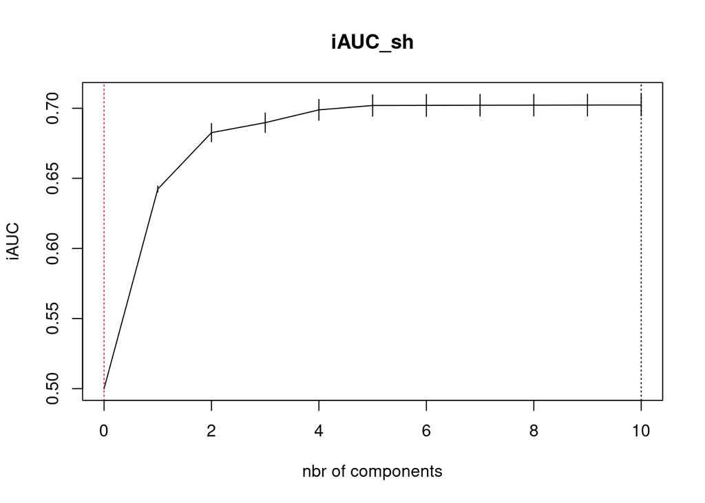

```r
fit <- plsRcox(est_dd2[, rid], time = est_dd2$OS.time, event = est_dd2$OS, nt = as.numeric(cv.plsRcox.res[5]))
```

```
## ____************************************************____
## ____Component____ 1 ____
## ____Component____ 2 ____
## ____Component____ 3 ____
## ____Component____ 4 ____
## ____Component____ 5 ____
## ____Component____ 6 ____
## ____Component____ 7 ____
## ____Component____ 8 ____
## ____Component____ 9 ____
## ____Component____ 10 ____
## ____Predicting X without NA neither in X nor in Y____
## ****________________________________________________****
```

```r
rs <- lapply(val_dd_list2, function(x){cbind(x[, 1:2], RS = as.numeric(predict(fit, type = "lp", newdata = x[, -c(1, 2)])))})
cc <- data.frame(Cindex = sapply(rs, function(x){as.numeric(summary(coxph(Surv(OS.time, OS) ~ RS, x))$concordance[1])})) %>%
  rownames_to_column('ID')
cc$Model <- paste0('RSF + ', 'plsRcox')
result <- rbind(result, cc)

## 1-7.RSF + Ridge
set.seed(seed)
fit <- rfsrc(Surv(OS.time, OS)~., data = est_dd,
             ntree = 1000, nodesize = rf_nodesize,
             splitrule = 'logrank',
             importance = T,
             proximity = T,
             forest = T,
             seed = seed)

vimp_result <- vimp(fit, importance = "permute")
importance_scores <- vimp_result$importance
rid <- names(sort(importance_scores, decreasing = TRUE))

# 3. 筛选重要变量（例如保留重要性 > 0 的变量）
# Filter important variables (e.g. keep those with importance > 0)
rid <- rid[importance_scores[rid] > 0]

est_dd2 <- est_data[, c('OS.time', 'OS', rid)]
val_dd_list2 <- lapply(val_data_list, function(x){x[, c('OS.time', 'OS', rid)]})
x1 <- as.matrix(est_dd2[, rid])
x2 <- as.matrix(Surv(est_dd2$OS.time, est_dd2$OS))
set.seed(seed)
fit = cv.glmnet(x1, x2,
                nfold=10,
                family = "binomial", alpha = 0,
                type.measure = "class")
rs <- lapply(val_dd_list2, function(x){cbind(x[, 1:2], RS = as.numeric(predict(fit, type = 'response', newx = as.matrix(x[, -c(1, 2)]), s = fit$lambda.min)))})
cc <- data.frame(Cindex = sapply(rs, function(x){as.numeric(summary(coxph(Surv(OS.time, OS) ~ RS, x))$concordance[1])})) %>%
  rownames_to_column('ID')
cc$Model <- paste0('RSF + ', 'Ridge')
result <- rbind(result, cc)

## 1-8.RSF + StepCox
set.seed(seed)
fit <- rfsrc(Surv(OS.time,OS)~., data = est_dd,
             ntree = 1000, nodesize = rf_nodesize,
             splitrule = 'logrank',
             importance = T,
             proximity = T,
             forest = T,
             seed = seed)

vimp_result <- vimp(fit, importance = "permute")
importance_scores <- vimp_result$importance
rid <- names(sort(importance_scores, decreasing = TRUE))

# 3. 筛选重要变量（例如保留重要性 > 0 的变量）
# Filter important variables (e.g. keep those with importance > 0)
rid <- rid[importance_scores[rid] > 0]

est_dd2 <- est_data[, c('OS.time', 'OS', rid)]
val_dd_list2 <- lapply(val_data_list, function(x){x[, c('OS.time', 'OS', rid)]})
for (direction in c("both", "backward", "forward")) {
  fit <- step(coxph(Surv(OS.time, OS)~., est_dd2), direction = direction)
  rs <- lapply(val_dd_list2, function(x){cbind(x[, 1:2], RS=predict(fit, type = 'risk', newdata = x))})
  cc <- data.frame(Cindex = sapply(rs, function(x){as.numeric(summary(coxph(Surv(OS.time, OS) ~ RS, x))$concordance[1])})) %>%
    rownames_to_column('ID')
  cc$Model <- paste0('RSF + ', 'StepCox', '[', direction, ']')
  result <- rbind(result, cc)
  }
```

```
## Start:  AIC=1227.95
## Surv(OS.time, OS) ~ FLJ16779 + MIR181A2HG + HMGN3.AS1 + CHKB.AS1 +
##     NIFK.AS1 + RP11.155O18.6 + RP11.710C12.1 + KB.431C1.5 + DLG3.AS1 +
##     RP11.449P15.2 + LSAMP.AS1 + RP3.368A4.6 + LPP.AS2 + INHBA.AS1 +
##     CCNT2.AS1 + LINC01270 + RP11.443B7.1 + RP11.1109F11.3 + NUTM2A.AS1 +
##     CASC15 + ROR1.AS1 + LINC01134 + SNHG5 + IL10RB.AS1 + LINC00205
##
##                  Df    AIC
## - ROR1.AS1        1 1226.0
## - LINC00205       1 1226.0
## - CASC15          1 1226.0
## - KB.431C1.5      1 1226.0
## - RP3.368A4.6     1 1226.0
## - CCNT2.AS1       1 1226.0
## - RP11.1109F11.3  1 1226.0
## - HMGN3.AS1       1 1226.0
## - LINC01270       1 1226.2
## - RP11.155O18.6   1 1226.2
## - LPP.AS2         1 1226.2
## - INHBA.AS1       1 1226.6
## - RP11.449P15.2   1 1226.7
## - NUTM2A.AS1      1 1226.9
## - SNHG5           1 1226.9
## - MIR181A2HG      1 1227.0
## - IL10RB.AS1      1 1227.2
## - FLJ16779        1 1227.3
## - CHKB.AS1        1 1227.7
## - RP11.710C12.1   1 1227.8
## <none>              1228.0
## - LINC01134       1 1230.9
## - LSAMP.AS1       1 1231.1
## - RP11.443B7.1    1 1235.0
## - DLG3.AS1        1 1235.2
## - NIFK.AS1        1 1240.0
##
## Step:  AIC=1225.95
## Surv(OS.time, OS) ~ FLJ16779 + MIR181A2HG + HMGN3.AS1 + CHKB.AS1 +
##     NIFK.AS1 + RP11.155O18.6 + RP11.710C12.1 + KB.431C1.5 + DLG3.AS1 +
##     RP11.449P15.2 + LSAMP.AS1 + RP3.368A4.6 + LPP.AS2 + INHBA.AS1 +
##     CCNT2.AS1 + LINC01270 + RP11.443B7.1 + RP11.1109F11.3 + NUTM2A.AS1 +
```

[output cut: 967 more lines]

```
## - CHKB.AS1       1 1204.9
## - RP11.710C12.1  1 1205.1
## - RP11.449P15.2  1 1206.5
## - LSAMP.AS1      1 1207.3
## - LINC01134      1 1207.8
## - MIR181A2HG     1 1210.3
## - RP11.443B7.1   1 1210.7
## - DLG3.AS1       1 1211.6
## - NIFK.AS1       1 1215.9
## Start:  AIC=1227.95
## Surv(OS.time, OS) ~ FLJ16779 + MIR181A2HG + HMGN3.AS1 + CHKB.AS1 +
##     NIFK.AS1 + RP11.155O18.6 + RP11.710C12.1 + KB.431C1.5 + DLG3.AS1 +
##     RP11.449P15.2 + LSAMP.AS1 + RP3.368A4.6 + LPP.AS2 + INHBA.AS1 +
##     CCNT2.AS1 + LINC01270 + RP11.443B7.1 + RP11.1109F11.3 + NUTM2A.AS1 +
##     CASC15 + ROR1.AS1 + LINC01134 + SNHG5 + IL10RB.AS1 + LINC00205
```

```r
## 1-9.RSF + SuperPC
set.seed(seed)
fit <- rfsrc(Surv(OS.time,OS)~., data = est_dd,
             ntree = 1000, nodesize = rf_nodesize,
             splitrule = 'logrank',
             importance = T,
             proximity = T,
             forest = T,
             seed = seed)

vimp_result <- vimp(fit, importance = "permute")
importance_scores <- vimp_result$importance
rid <- names(sort(importance_scores, decreasing = TRUE))

# 3. 筛选重要变量（例如保留重要性 > 0 的变量）
# Filter important variables (e.g. keep those with importance > 0)
rid <- rid[importance_scores[rid] > 0]

est_dd2 <- est_data[, c('OS.time', 'OS', rid)]
val_dd_list2 <- lapply(val_data_list, function(x){x[, c('OS.time', 'OS', rid)]})
data <- list(x = t(est_dd2[, -c(1, 2)]), y = est_dd2$OS.time,
             censoring.status = est_dd2$OS,
             featurenames = colnames(est_dd2)[-c(1, 2)])
set.seed(seed)
fit <- superpc.train(data = data, type = 'survival', s0.perc = 0.5)
cv.fit <- superpc.cv(fit, data, n.threshold = 20,
                     n.fold = 10,
                     n.components = 3,
                     min.features = 5,
                     max.features = nrow(data$x),
                     compute.fullcv = TRUE,
                     compute.preval = TRUE)
rs <- lapply(val_dd_list2, function(w){
  test <- list(x = t(w[, -c(1, 2)]), y = w$OS.time, censoring.status=w$OS, featurenames = colnames(w)[-c(1, 2)])
  ff <- superpc.predict(fit, data, test, threshold = cv.fit$thresholds[which.max(cv.fit[["scor"]][1, ])], n.components = 1)
  rr <- as.numeric(ff$v.pred)
  rr2 <- cbind(w[, 1:2], RS = rr)
  return(rr2)
  })
cc <- data.frame(Cindex=sapply(rs, function(x){as.numeric(summary(coxph(Surv(OS.time, OS) ~ RS, x))$concordance[1])}))%>%
  rownames_to_column('ID')
cc$Model <- paste0('RSF + ', 'SuperPC')
result <- rbind(result, cc)

## 1-10.RSF + survival-SVM
set.seed(seed)
fit <- rfsrc(Surv(OS.time, OS)~., data = est_dd,
             ntree = 1000, nodesize = rf_nodesize,
             splitrule = 'logrank',
             importance = T,
             proximity = T,
             forest = T,
             seed = seed)

vimp_result <- vimp(fit, importance = "permute")
importance_scores <- vimp_result$importance
rid <- names(sort(importance_scores, decreasing = TRUE))

# 3. 筛选重要变量（例如保留重要性 > 0 的变量）
# Filter important variables (e.g. keep those with importance > 0)
rid <- rid[importance_scores[rid] > 0]

est_dd2 <- est_data[, c('OS.time', 'OS', rid)]
val_dd_list2 <- lapply(val_data_list, function(x){x[, c('OS.time', 'OS', rid)]})
fit = survivalsvm(Surv(OS.time, OS)~., data= est_dd2, gamma.mu = 1)
rs <- lapply(val_dd_list2, function(x){cbind(x[, 1:2], RS=as.numeric(predict(fit, x)$predicted))})
cc <- data.frame(Cindex = sapply(rs, function(x){as.numeric(summary(coxph(Surv(OS.time, OS) ~ RS, x))$concordance[1])})) %>%
  rownames_to_column('ID')
cc$Model <- paste0('RSF + ', 'survival-SVM')
result <- rbind(result,cc)
```

# 2.Enet

```r
x1 <- as.matrix(est_dd[, pre_var])
x2 <- as.matrix(Surv(est_dd$OS.time, est_dd$OS))
for (alpha in seq(0.1, 0.9, 0.1)) {
  set.seed(seed)
  fit = cv.glmnet(x1, x2, family = "cox", alpha = alpha, nfolds = 10)
  rs <- lapply(val_dd_list,function(x){cbind(x[, 1:2], RS = as.numeric(predict(fit,type = 'link', newx = as.matrix(x[,-c(1,2)]), s = fit$lambda.min)))})
  cc <- data.frame(Cindex = sapply(rs,function(x){as.numeric(summary(coxph(Surv(OS.time, OS) ~ RS, x))$concordance[1])})) %>%
    rownames_to_column('ID')
  cc$Model <- paste0('Enet', '[α=', alpha, ']')
  result <- rbind(result, cc)
  }
```

# 3.StepCox

```r
for (direction in c("both", "backward", "forward")) {
  fit <- step(coxph(Surv(OS.time,OS)~., est_dd), direction = direction)
  rs <- lapply(val_dd_list,function(x){cbind(x[, 1:2], RS = predict(fit, type = 'risk', newdata = x))})
  cc <- data.frame(Cindex = sapply(rs, function(x){as.numeric(summary(coxph(Surv(OS.time, OS) ~ RS, x))$concordance[1])})) %>%
    rownames_to_column('ID')
  cc$Model <- paste0('StepCox', '[', direction, ']')
  result <- rbind(result, cc)
  }
```

```
## Start:  AIC=1228.32
## Surv(OS.time, OS) ~ SNHG5 + LINC01270 + CHKB.AS1 + NUTM2A.AS1 +
##     LINC00205 + IL10RB.AS1 + ROR1.AS1 + MIR181A2HG + CCNT2.AS1 +
##     INHBA.AS1 + AC007365.3 + DLG3.AS1 + LINC01134 + NIFK.AS1 +
##     RP11.443B7.1 + LSAMP.AS1 + HMGN3.AS1 + LPP.AS2 + RP11.1109F11.3 +
##     RP11.710C12.1 + RP3.368A4.6 + KB.431C1.5 + RP11.155O18.6 +
##     CASC15 + RP11.449P15.2 + FLJ16779
##
##                  Df    AIC
## - HMGN3.AS1       1 1226.3
## - RP3.368A4.6     1 1226.3
## - CASC15          1 1226.3
## - LINC00205       1 1226.3
## - CCNT2.AS1       1 1226.4
## - ROR1.AS1        1 1226.4
## - RP11.1109F11.3  1 1226.4
## - KB.431C1.5      1 1226.5
## - INHBA.AS1       1 1226.5
## - RP11.155O18.6   1 1226.6
## - LINC01270       1 1226.7
## - RP11.449P15.2   1 1226.9
## - LPP.AS2         1 1226.9
## - NUTM2A.AS1      1 1226.9
## - RP11.710C12.1   1 1227.2
## - SNHG5           1 1227.4
## - IL10RB.AS1      1 1227.5
## - MIR181A2HG      1 1227.5
## - FLJ16779        1 1227.8
## - AC007365.3      1 1228.0
## - CHKB.AS1        1 1228.1
## <none>              1228.3
## - LINC01134       1 1231.1
## - LSAMP.AS1       1 1231.6
## - DLG3.AS1        1 1235.7
## - RP11.443B7.1    1 1236.3
## - NIFK.AS1        1 1240.8
##
## Step:  AIC=1226.33
## Surv(OS.time, OS) ~ SNHG5 + LINC01270 + CHKB.AS1 + NUTM2A.AS1 +
##     LINC00205 + IL10RB.AS1 + ROR1.AS1 + MIR181A2HG + CCNT2.AS1 +
```

[output cut: 1084 more lines]

```
## - AC007365.3     1 1205.6
## - MIR181A2HG     1 1206.8
## - CHKB.AS1       1 1207.8
## - LSAMP.AS1      1 1208.7
## - LINC01134      1 1210.4
## - DLG3.AS1       1 1211.6
## - RP11.443B7.1   1 1212.1
## - NIFK.AS1       1 1218.3
## Start:  AIC=1228.32
## Surv(OS.time, OS) ~ SNHG5 + LINC01270 + CHKB.AS1 + NUTM2A.AS1 +
##     LINC00205 + IL10RB.AS1 + ROR1.AS1 + MIR181A2HG + CCNT2.AS1 +
##     INHBA.AS1 + AC007365.3 + DLG3.AS1 + LINC01134 + NIFK.AS1 +
##     RP11.443B7.1 + LSAMP.AS1 + HMGN3.AS1 + LPP.AS2 + RP11.1109F11.3 +
##     RP11.710C12.1 + RP3.368A4.6 + KB.431C1.5 + RP11.155O18.6 +
##     CASC15 + RP11.449P15.2 + FLJ16779
```

```r
for (direction in c("both", "backward", "forward")) {
  fit <- step(coxph(Surv(OS.time, OS)~., est_dd), direction = direction)
  rid <- names(coef(fit))#这里不用卡P值，迭代的结果就是可以纳入的基因
  est_dd2 <- est_data[,c('OS.time', 'OS', rid)]
  val_dd_list2 <- lapply(val_data_list, function(x){x[, c('OS.time', 'OS', rid)]})
  set.seed(seed)
  pen <- optimCoxBoostPenalty(est_dd2[, 'OS.time'], est_dd2[, 'OS'], as.matrix(est_dd2[, -c(1,2)]),
                              trace=TRUE, start.penalty = 500, parallel = T)
  cv.res <- cv.CoxBoost(est_dd2[, 'OS.time'], est_dd2[, 'OS'], as.matrix(est_dd2[, -c(1,2)]),
                        maxstepno = 500, K = 10 , type = "verweij", penalty = pen$penalty)
  fit <- CoxBoost(est_dd2[, 'OS.time'], est_dd2[, 'OS'], as.matrix(est_dd2[, -c(1, 2)]),
                  stepno = cv.res$optimal.step, penalty = pen$penalty)
  rs <- lapply(val_dd_list2, function(x){cbind(x[, 1:2], RS = as.numeric(predict(fit, newdata = x[, -c(1, 2)], newtime=x[, 1], newstatus=x[,2], type="lp")))})
  cc <- data.frame(Cindex = sapply(rs,function(x){as.numeric(summary(coxph(Surv(OS.time, OS) ~ RS, x))$concordance[1])})) %>%
    rownames_to_column('ID')
  cc$Model <- paste0('StepCox', '[', direction, ']', ' + CoxBoost')
  result <- rbind(result, cc)
  x1 <- as.matrix(est_dd2[, rid])
  x2 <- as.matrix(Surv(est_dd2$OS.time, est_dd2$OS))
  for (alpha in seq(0.1, 0.9, 0.1)) {
    set.seed(seed)
    fit = cv.glmnet(x1, x2, family = "cox",alpha = alpha, nfolds = 10)
    rs <- lapply(val_dd_list2, function(x){cbind(x[, 1:2], RS = as.numeric(predict(fit, type = 'link', newx = as.matrix(x[, -c(1, 2)]), s = fit$lambda.min)))})
    cc <- data.frame(Cindex = sapply(rs,function(x){as.numeric(summary(coxph(Surv(OS.time, OS) ~ RS, x))$concordance[1])})) %>%
      rownames_to_column('ID')
    cc$Model <- paste0('StepCox', '[', direction, ']', ' + Enet', '[α=', alpha, ']')
    result <- rbind(result, cc)
    }
  set.seed(seed)
  fit <- gbm(formula = Surv(OS.time, OS)~., data = est_dd2, distribution = 'coxph',
             n.trees = 10000,
             interaction.depth = 3,
             n.minobsinnode = 10,
             shrinkage = 0.001,
             cv.folds = 10,n.cores = 6)

  # 找到具有最小交叉验证误差的树数量索引
  # find index for number trees with minimum CV error
  best <- which.min(fit$cv.error)

  set.seed(seed)
  fit <- gbm(formula = Surv(OS.time, OS)~., data = est_dd2, distribution = 'coxph',
             n.trees = best,
             interaction.depth = 3,
             n.minobsinnode = 10,
             shrinkage = 0.001,
             cv.folds = 10,n.cores = 8)
  rs <- lapply(val_dd_list2, function(x){cbind(x[,1:2], RS = as.numeric(predict(fit, x, n.trees = best, type = 'link')))})
  cc <- data.frame(Cindex=sapply(rs, function(x){as.numeric(summary(coxph(Surv(OS.time, OS) ~ RS, x))$concordance[1])})) %>%
    rownames_to_column('ID')
  cc$Model <- paste0('StepCox', '[', direction, ']', ' + GBM')
  result <- rbind(result, cc)
  x1 <- as.matrix(est_dd2[, rid])
  x2 <- as.matrix(Surv(est_dd2$OS.time, est_dd2$OS))
  set.seed(seed)
  fit = cv.glmnet(x1, x2,
                  nfold=10, #例文描述：10-fold cross-validation
                  family = "binomial", alpha = 1,
                  type.measure = "class")
  rs <- lapply(val_dd_list2, function(x){cbind(x[,1:2], RS = as.numeric(predict(fit, type = 'response', newx = as.matrix(x[, -c(1, 2)]), s = fit$lambda.min)))})
  cc <- data.frame(Cindex = sapply(rs, function(x){as.numeric(summary(coxph(Surv(OS.time, OS) ~ RS, x))$concordance[1])})) %>%
    rownames_to_column('ID')
  cc$Model <- paste0('StepCox', '[', direction, ']', ' + Lasso')
  result <- rbind(result, cc)
  set.seed(seed)
  cv.plsRcox.res = cv.plsRcox(list(x = est_dd2[,rid], time = est_dd2$OS.time, status = est_dd2$OS), nt = 10, verbose = FALSE)
  fit <- plsRcox(est_dd2[, rid], time = est_dd2$OS.time,
                 event = est_dd2$OS, nt = as.numeric(cv.plsRcox.res[5]))
  rs <- lapply(val_dd_list2, function(x){cbind(x[, 1:2], RS = as.numeric(predict(fit, type = "lp", newdata = x[, -c(1,2)])))})
  cc <- data.frame(Cindex = sapply(rs, function(x){as.numeric(summary(coxph(Surv(OS.time, OS) ~ RS, x))$concordance[1])})) %>%
    rownames_to_column('ID')
  cc$Model <- paste0('StepCox', '[', direction, ']', ' + plsRcox')
  result <- rbind(result, cc)
  x1 <- as.matrix(est_dd2[, rid])
  x2 <- as.matrix(Surv(est_dd2$OS.time, est_dd2$OS))
  set.seed(seed)
  fit = cv.glmnet(x1, x2,
                  nfold = 10, #例文描述：10-fold cross-validation
                  family = "binomial", alpha = 0,
                  type.measure = "class")
  rs <- lapply(val_dd_list2, function(x){cbind(x[,1:2], RS = as.numeric(predict(fit, type = 'response', newx = as.matrix(x[, -c(1, 2)]), s = fit$lambda.min)))})
  cc <- data.frame(Cindex = sapply(rs, function(x){as.numeric(summary(coxph(Surv(OS.time, OS) ~ RS, x))$concordance[1])})) %>%
    rownames_to_column('ID')
  cc$Model <- paste0('StepCox', '[', direction, ']', ' + Ridge')
  result <- rbind(result, cc)
  set.seed(seed)
  fit <- rfsrc(Surv(OS.time,OS)~., data = est_dd2,
               ntree = 1000, nodesize = rf_nodesize, #该值建议多调整
               splitrule = 'logrank',
               importance = T,
               proximity = T,
               forest = T,
               seed = seed)
  rs <- lapply(val_dd_list2, function(x){cbind(x[, 1:2], RS = predict(fit, newdata = x)$predicted)})
  cc <- data.frame(Cindex = sapply(rs, function(x){as.numeric(summary(coxph(Surv(OS.time, OS) ~ RS, x))$concordance[1])})) %>%
    rownames_to_column('ID')
  cc$Model <- paste0('StepCox', '[', direction, ']', ' + RSF')
  result <- rbind(result, cc)
  data <- list(x = t(est_dd2[, -c(1, 2)]), y = est_dd2$OS.time,
               censoring.status = est_dd2$OS,
               featurenames = colnames(est_dd2)[-c(1,2)])
  set.seed(seed)
  fit <- superpc.train(data = data,type = 'survival', s0.perc = 0.5) #default
  cv.fit <- superpc.cv(fit, data, n.threshold = 20, #default
                       n.fold = 10,
                       n.components = 3,
                       min.features = 5,
                       max.features = nrow(data$x),
                       compute.fullcv = TRUE,
                       compute.preval = TRUE)
  rs <- lapply(val_dd_list2, function(w){
    test <- list(x = t(w[, -c(1,2)]), y = w$OS.time, censoring.status = w$OS, featurenames = colnames(w)[-c(1,2)])
    ff <- superpc.predict(fit, data, test, threshold = cv.fit$thresholds[which.max(cv.fit[["scor"]][1,])], n.components = 1)
    rr <- as.numeric(ff$v.pred)
    rr2 <- cbind(w[,1:2], RS = rr)
    return(rr2)
    })
  cc <- data.frame(Cindex = sapply(rs, function(x){as.numeric(summary(coxph(Surv(OS.time, OS) ~ RS, x))$concordance[1])})) %>%
    rownames_to_column('ID')
  cc$Model <- paste0('StepCox', '[', direction, ']', ' + SuperPC')
  result <- rbind(result, cc)
  fit = survivalsvm(Surv(OS.time,OS)~., data = est_dd2, gamma.mu = 1)
  rs <- lapply(val_dd_list2, function(x){cbind(x[, 1:2], RS = as.numeric(predict(fit, x)$predicted))})
  cc <- data.frame(Cindex = sapply(rs, function(x){as.numeric(summary(coxph(Surv(OS.time, OS) ~ RS, x))$concordance[1])})) %>%
    rownames_to_column('ID')
  cc$Model <- paste0('StepCox', '[', direction, ']', ' + survival-SVM')
  result <- rbind(result, cc)
  }
```

```
## Start:  AIC=1228.32
## Surv(OS.time, OS) ~ SNHG5 + LINC01270 + CHKB.AS1 + NUTM2A.AS1 +
##     LINC00205 + IL10RB.AS1 + ROR1.AS1 + MIR181A2HG + CCNT2.AS1 +
##     INHBA.AS1 + AC007365.3 + DLG3.AS1 + LINC01134 + NIFK.AS1 +
##     RP11.443B7.1 + LSAMP.AS1 + HMGN3.AS1 + LPP.AS2 + RP11.1109F11.3 +
##     RP11.710C12.1 + RP3.368A4.6 + KB.431C1.5 + RP11.155O18.6 +
##     CASC15 + RP11.449P15.2 + FLJ16779
##
##                  Df    AIC
## - HMGN3.AS1       1 1226.3
## - RP3.368A4.6     1 1226.3
## - CASC15          1 1226.3
## - LINC00205       1 1226.3
## - CCNT2.AS1       1 1226.4
## - ROR1.AS1        1 1226.4
## - RP11.1109F11.3  1 1226.4
## - KB.431C1.5      1 1226.5
## - INHBA.AS1       1 1226.5
## - RP11.155O18.6   1 1226.6
## - LINC01270       1 1226.7
## - RP11.449P15.2   1 1226.9
## - LPP.AS2         1 1226.9
## - NUTM2A.AS1      1 1226.9
## - RP11.710C12.1   1 1227.2
## - SNHG5           1 1227.4
## - IL10RB.AS1      1 1227.5
## - MIR181A2HG      1 1227.5
## - FLJ16779        1 1227.8
## - AC007365.3      1 1228.0
## - CHKB.AS1        1 1228.1
## <none>              1228.3
## - LINC01134       1 1231.1
## - LSAMP.AS1       1 1231.6
## - DLG3.AS1        1 1235.7
## - RP11.443B7.1    1 1236.3
## - NIFK.AS1        1 1240.8
##
## Step:  AIC=1226.33
## Surv(OS.time, OS) ~ SNHG5 + LINC01270 + CHKB.AS1 + NUTM2A.AS1 +
##     LINC00205 + IL10RB.AS1 + ROR1.AS1 + MIR181A2HG + CCNT2.AS1 +
```

[output cut: 613 more lines]

```
## + SNHG5           1 1205.4
## + RP11.710C12.1   1 1205.4
## + HMGN3.AS1       1 1205.5
## + IL10RB.AS1      1 1205.7
## + CCNT2.AS1       1 1205.8
## + LINC00205       1 1205.8
## + INHBA.AS1       1 1205.8
## + ROR1.AS1        1 1205.8
## - RP11.155O18.6   1 1206.2
## - MIR181A2HG      1 1207.9
## - LINC01134       1 1208.0
## - LSAMP.AS1       1 1209.5
## - DLG3.AS1        1 1210.8
## - RP11.443B7.1    1 1213.2
## - NIFK.AS1        1 1216.5
```

```
## iteration 1 : evaluating penalty 500
```

[output not shown]

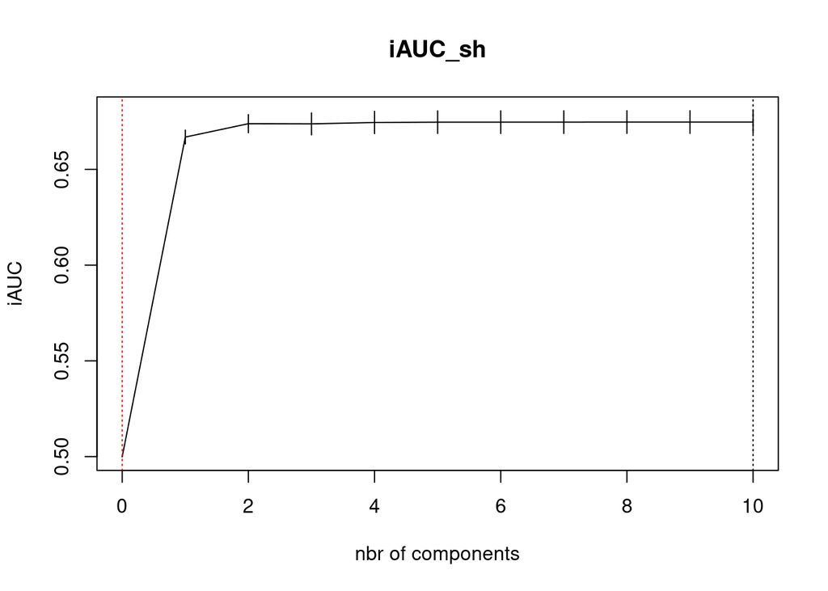

```
## ____************************************************____
## ____Component____ 1 ____
## ____Component____ 2 ____
## ____Component____ 3 ____
## ____Component____ 4 ____
## ____Component____ 5 ____
## ____Component____ 6 ____
## ____Component____ 7 ____
## ____Component____ 8 ____
## ____Component____ 9 ____
## ____Component____ 10 ____
## ____Predicting X without NA neither in X nor in Y____
## ****________________________________________________****
##
## Start:  AIC=1228.32
## Surv(OS.time, OS) ~ SNHG5 + LINC01270 + CHKB.AS1 + NUTM2A.AS1 +
##     LINC00205 + IL10RB.AS1 + ROR1.AS1 + MIR181A2HG + CCNT2.AS1 +
##     INHBA.AS1 + AC007365.3 + DLG3.AS1 + LINC01134 + NIFK.AS1 +
##     RP11.443B7.1 + LSAMP.AS1 + HMGN3.AS1 + LPP.AS2 + RP11.1109F11.3 +
##     RP11.710C12.1 + RP3.368A4.6 + KB.431C1.5 + RP11.155O18.6 +
##     CASC15 + RP11.449P15.2 + FLJ16779
##
##                  Df    AIC
## - HMGN3.AS1       1 1226.3
## - RP3.368A4.6     1 1226.3
## - CASC15          1 1226.3
## - LINC00205       1 1226.3
## - CCNT2.AS1       1 1226.4
## - ROR1.AS1        1 1226.4
## - RP11.1109F11.3  1 1226.4
## - KB.431C1.5      1 1226.5
## - INHBA.AS1       1 1226.5
## - RP11.155O18.6   1 1226.6
## - LINC01270       1 1226.7
## - RP11.449P15.2   1 1226.9
## - LPP.AS2         1 1226.9
## - NUTM2A.AS1      1 1226.9
## - RP11.710C12.1   1 1227.2
## - SNHG5           1 1227.4
## - IL10RB.AS1      1 1227.5
```

[output cut: 423 more lines]

```
##     LINC01134 + NIFK.AS1 + RP11.443B7.1 + LSAMP.AS1 + RP11.155O18.6 +
##     FLJ16779
##
##                 Df    AIC
## <none>             1204.5
## - FLJ16779       1 1204.8
## - RP11.155O18.6  1 1205.2
## - AC007365.3     1 1205.6
## - MIR181A2HG     1 1206.8
## - CHKB.AS1       1 1207.8
## - LSAMP.AS1      1 1208.7
## - LINC01134      1 1210.4
## - DLG3.AS1       1 1211.6
## - RP11.443B7.1   1 1212.1
## - NIFK.AS1       1 1218.3
```

```
## iteration 1 : evaluating penalty 500
```

[output not shown]

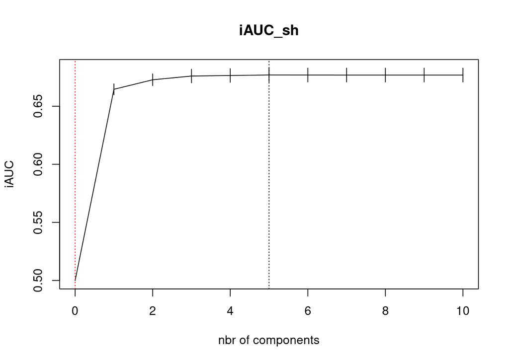

```
## ____************************************************____
## ____Component____ 1 ____
## ____Component____ 2 ____
## ____Component____ 3 ____
## ____Component____ 4 ____
## ____Component____ 5 ____
## ____Predicting X without NA neither in X nor in Y____
## ****________________________________________________****
##
## Start:  AIC=1228.32
## Surv(OS.time, OS) ~ SNHG5 + LINC01270 + CHKB.AS1 + NUTM2A.AS1 +
##     LINC00205 + IL10RB.AS1 + ROR1.AS1 + MIR181A2HG + CCNT2.AS1 +
##     INHBA.AS1 + AC007365.3 + DLG3.AS1 + LINC01134 + NIFK.AS1 +
##     RP11.443B7.1 + LSAMP.AS1 + HMGN3.AS1 + LPP.AS2 + RP11.1109F11.3 +
##     RP11.710C12.1 + RP3.368A4.6 + KB.431C1.5 + RP11.155O18.6 +
##     CASC15 + RP11.449P15.2 + FLJ16779
```

```
## iteration 1 : evaluating penalty 500
```

[output not shown]

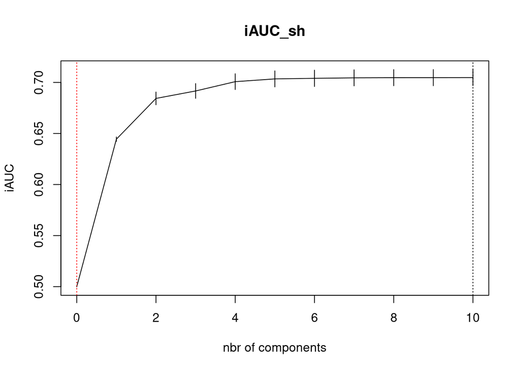

```
## ____************************************************____
## ____Component____ 1 ____
## ____Component____ 2 ____
## ____Component____ 3 ____
## ____Component____ 4 ____
## ____Component____ 5 ____
## ____Component____ 6 ____
## ____Component____ 7 ____
## ____Component____ 8 ____
## ____Component____ 9 ____
## ____Component____ 10 ____
## ____Predicting X without NA neither in X nor in Y____
## ****________________________________________________****
```

# 4.CoxBoost

```r
## 4-1.CoxBoost
set.seed(seed)
pen <- optimCoxBoostPenalty(est_dd[, 'OS.time'], est_dd[, 'OS'], as.matrix(est_dd[, -c(1,2)]),
                            trace = TRUE, start.penalty = 500, parallel = T)
```

```
## iteration 1 : evaluating penalty 500
```

[output not shown]

```r
cv.res <- cv.CoxBoost(est_dd[, 'OS.time'], est_dd[, 'OS'], as.matrix(est_dd[, -c(1,2)]), maxstepno = 500, K = 10, type = "verweij", penalty = pen$penalty)
fit <- CoxBoost(est_dd[, 'OS.time'], est_dd[, 'OS'], as.matrix(est_dd[, -c(1,2)]),
                stepno = cv.res$optimal.step, penalty = pen$penalty)
rs <- lapply(val_dd_list, function(x){cbind(x[,1:2], RS = as.numeric(predict(fit, newdata = x[, -c(1,2)], newtime = x[,1], newstatus = x[,2], type = "lp")))})
cc <- data.frame(Cindex = sapply(rs,function(x){as.numeric(summary(coxph(Surv(OS.time, OS) ~ RS, x))$concordance[1])})) %>%
  rownames_to_column('ID')
cc$Model <- paste0('CoxBoost')
result <- rbind(result, cc)

## 4-2.CoxBoost + Enet
set.seed(seed)
pen <- optimCoxBoostPenalty(est_dd[, 'OS.time'], est_dd[, 'OS'], as.matrix(est_dd[, -c(1,2)]),
                            trace = TRUE, start.penalty = 500, parallel = T)
```

```
## iteration 1 : evaluating penalty 500
```

[output not shown]

```r
cv.res <- cv.CoxBoost(est_dd[, 'OS.time'], est_dd[, 'OS'], as.matrix(est_dd[, -c(1,2)]),
                      maxstepno = 500, K = 10, type = "verweij", penalty = pen$penalty)
fit <- CoxBoost(est_dd[, 'OS.time'], est_dd[, 'OS'], as.matrix(est_dd[, -c(1,2)]),
                stepno = cv.res$optimal.step, penalty = pen$penalty)
rid <- as.data.frame(coef(fit))
rid$id <- rownames(rid)
rid <- rid[which(rid$`coef(fit)`!=0), "id"]
est_dd2 <- est_data[, c('OS.time', 'OS', rid)]
val_dd_list2 <- lapply(val_data_list, function(x){x[, c('OS.time', 'OS', rid)]})
x1 <- as.matrix(est_dd2[, rid])
x2 <- as.matrix(Surv(est_dd2$OS.time, est_dd2$OS))
for (alpha in seq(0.1, 0.9, 0.1)) {
  set.seed(seed)
  fit = cv.glmnet(x1, x2, family = "cox", alpha = alpha, nfolds = 10)
  rs <- lapply(val_dd_list2, function(x){cbind(x[, 1:2], RS = as.numeric(predict(fit, type = 'link', newx = as.matrix(x[, -c(1,2)]), s = fit$lambda.min)))})
  cc <- data.frame(Cindex = sapply(rs, function(x){as.numeric(summary(coxph(Surv(OS.time, OS) ~ RS, x))$concordance[1])})) %>%
    rownames_to_column('ID')
  cc$Model <- paste0('CoxBoost', ' + Enet', '[α=', alpha, ']')
  result <- rbind(result, cc)
  }

## 4-3.CoxBoost + GBM
set.seed(seed)
pen <- optimCoxBoostPenalty(est_dd[, 'OS.time'], est_dd[, 'OS'], as.matrix(est_dd[, -c(1,2)]),
                                          trace = TRUE, start.penalty = 500, parallel = T)
```

```
## iteration 1 : evaluating penalty 500
```

[output not shown]

```r
cv.res <- cv.CoxBoost(est_dd[, 'OS.time'], est_dd[, 'OS'], as.matrix(est_dd[, -c(1,2)]),
                                    maxstepno = 500, K= 10, type = "verweij", penalty = pen$penalty)
fit <- CoxBoost(est_dd[, 'OS.time'], est_dd[, 'OS'], as.matrix(est_dd[, -c(1,2)]),
                              stepno = cv.res$optimal.step, penalty = pen$penalty)
rid <- as.data.frame(coef(fit))
rid$id <- rownames(rid)
rid <- rid[which(rid$`coef(fit)`!=0), "id"]
est_dd2 <- est_data[, c('OS.time', 'OS', rid)]
val_dd_list2 <- lapply(val_data_list, function(x){x[,c('OS.time', 'OS', rid)]})
set.seed(seed)
fit <- gbm(formula = Surv(OS.time,OS)~., data = est_dd2, distribution = 'coxph',
           n.trees = 10000,
           interaction.depth = 3,
           n.minobsinnode = 10,
           shrinkage = 0.001,
           cv.folds = 10, n.cores = 6)

# 找到具有最小交叉验证误差的树数量索引
# find index for number trees with minimum CV error
best <- which.min(fit$cv.error)

set.seed(seed)
fit <- gbm(formula = Surv(OS.time,OS)~., data = est_dd2, distribution = 'coxph',
           n.trees = best,
           interaction.depth = 3,
           n.minobsinnode = 10,
           shrinkage = 0.001,
           cv.folds = 10,n.cores = 8)
rs <- lapply(val_dd_list2,function(x){cbind(x[, 1:2], RS = as.numeric(predict(fit, x, n.trees = best, type = 'link')))})
cc <- data.frame(Cindex=sapply(rs, function(x){as.numeric(summary(coxph(Surv(OS.time, OS) ~ RS, x))$concordance[1])})) %>%
  rownames_to_column('ID')
cc$Model <- paste0('CoxBoost + ', 'GBM')
result <- rbind(result, cc)

## 4-4.CoxBoost + Lasso
set.seed(seed)
pen <- optimCoxBoostPenalty(est_dd[, 'OS.time'], est_dd[, 'OS'], as.matrix(est_dd[, -c(1,2)]),
                                          trace = TRUE, start.penalty = 500, parallel = T)
```

```
## iteration 1 : evaluating penalty 500
```

[output not shown]

```r
cv.res <- cv.CoxBoost(est_dd[, 'OS.time'], est_dd[, 'OS'], as.matrix(est_dd[, -c(1,2)]),
                                    maxstepno = 500, K = 10, type = "verweij", penalty = pen$penalty)
fit <- CoxBoost(est_dd[, 'OS.time'], est_dd[, 'OS'], as.matrix(est_dd[, -c(1,2)]),
                              stepno=cv.res$optimal.step, penalty=pen$penalty)
rid <- as.data.frame(coef(fit))
rid$id <- rownames(rid)
rid <- rid[which(rid$`coef(fit)` != 0), "id"]
est_dd2 <- est_data[,c('OS.time', 'OS', rid)]
val_dd_list2 <- lapply(val_data_list, function(x){x[, c('OS.time', 'OS', rid)]})
x1 <- as.matrix(est_dd2[, rid])
x2 <- as.matrix(Surv(est_dd2$OS.time, est_dd2$OS))
set.seed(seed)
fit = cv.glmnet(x1, x2,
                nfold = 10,
                family = "binomial", alpha = 1,
                type.measure = "class")
rs <- lapply(val_dd_list2, function(x){cbind(x[,1:2], RS = as.numeric(predict(fit, type = 'response', newx = as.matrix(x[, -c(1,2)]), s = fit$lambda.min)))})
cc <- data.frame(Cindex = sapply(rs, function(x){as.numeric(summary(coxph(Surv(OS.time, OS) ~ RS, x))$concordance[1])})) %>%
  rownames_to_column('ID')
cc$Model <- paste0('CoxBoost + ', 'Lasso')
result <- rbind(result, cc)

## 4-5.CoxBoost + plsRcox
set.seed(seed)
pen <- optimCoxBoostPenalty(est_dd[, 'OS.time'], est_dd[, 'OS'], as.matrix(est_dd[, -c(1,2)]),
                                          trace = TRUE, start.penalty = 500, parallel = T)
```

```
## iteration 1 : evaluating penalty 500
```

[output not shown]

```r
cv.res <- cv.CoxBoost(est_dd[, 'OS.time'], est_dd[, 'OS'], as.matrix(est_dd[, -c(1,2)]),
                                    maxstepno = 500, K = 10, type = "verweij", penalty = pen$penalty)
fit <- CoxBoost(est_dd[, 'OS.time'], est_dd[, 'OS'], as.matrix(est_dd[, -c(1,2)]),
                              stepno = cv.res$optimal.step, penalty = pen$penalty)
rid <- as.data.frame(coef(fit))
rid$id <- rownames(rid)
rid <- rid[which(rid$`coef(fit)` != 0), "id"]
est_dd2 <- est_data[,c('OS.time', 'OS', rid)]
val_dd_list2 <- lapply(val_data_list, function(x){x[,c('OS.time', 'OS', rid)]})
set.seed(seed)
cv.plsRcox.res = cv.plsRcox(list(x = est_dd2[,rid], time = est_dd2$OS.time, status = est_dd2$OS), nt = 10, verbose = FALSE)
```

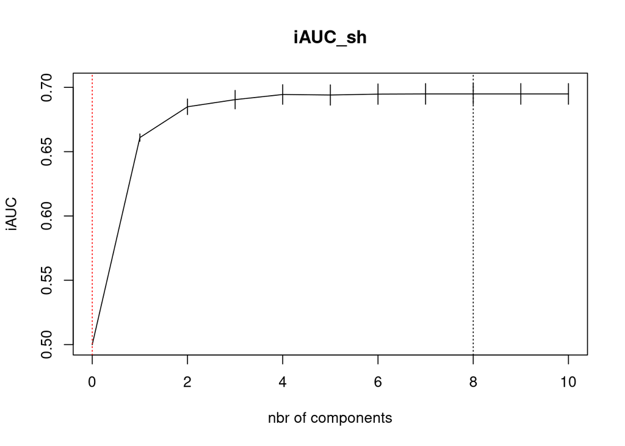

```r
fit <- plsRcox(est_dd2[, rid], time = est_dd2$OS.time, event = est_dd2$OS, nt = as.numeric(cv.plsRcox.res[5]))
```

```
## ____************************************************____
## ____Component____ 1 ____
## ____Component____ 2 ____
## ____Component____ 3 ____
## ____Component____ 4 ____
## ____Component____ 5 ____
## ____Component____ 6 ____
## ____Component____ 7 ____
```

```
## ____Component____ 8 ____
## ____Predicting X without NA neither in X nor in Y____
## ****________________________________________________****
```

```r
rs <- lapply(val_dd_list2, function(x){cbind(x[,1:2], RS = as.numeric(predict(fit, type="lp", newdata = x[, -c(1,2)])))})
cc <- data.frame(Cindex = sapply(rs, function(x){as.numeric(summary(coxph(Surv(OS.time, OS) ~ RS, x))$concordance[1])})) %>%
  rownames_to_column('ID')
cc$Model <- paste0('CoxBoost + ', 'plsRcox')
result <- rbind(result, cc)

## 4-6.CoxBoost + Ridge
set.seed(seed)
pen <- optimCoxBoostPenalty(est_dd[, 'OS.time'], est_dd[, 'OS'], as.matrix(est_dd[, -c(1,2)]),
                                          trace = TRUE, start.penalty = 500, parallel = T)
```

```
## iteration 1 : evaluating penalty 500
```

[output not shown]

```r
cv.res <- cv.CoxBoost(est_dd[, 'OS.time'], est_dd[, 'OS'], as.matrix(est_dd[, -c(1,2)]),
                      maxstepno = 500, K=10, type="verweij", penalty = pen$penalty)
fit <- CoxBoost(est_dd[, 'OS.time'], est_dd[, 'OS'], as.matrix(est_dd[, -c(1,2)]),
                stepno = cv.res$optimal.step, penalty = pen$penalty)
rid <- as.data.frame(coef(fit))
rid$id <- rownames(rid)
rid <- rid[which(rid$`coef(fit)` != 0), "id"]
est_dd2 <- est_data[,c('OS.time', 'OS', rid)]
val_dd_list2 <- lapply(val_data_list, function(x){x[,c('OS.time', 'OS', rid)]})
x1 <- as.matrix(est_dd2[, rid])
x2 <- as.matrix(Surv(est_dd2$OS.time, est_dd2$OS))
set.seed(seed)
fit = cv.glmnet(x1, x2,
                nfold=10,
                family = "binomial", alpha = 0,
                type.measure = "class")
rs <- lapply(val_dd_list2, function(x){cbind(x[,1:2], RS = as.numeric(predict(fit, type = 'response', newx = as.matrix(x[, -c(1,2)]), s = fit$lambda.min)))})
cc <- data.frame(Cindex = sapply(rs,function(x){as.numeric(summary(coxph(Surv(OS.time, OS) ~ RS, x))$concordance[1])})) %>%
  rownames_to_column('ID')
cc$Model <- paste0('CoxBoost + ', 'Ridge')
result <- rbind(result, cc)

## 4-7.CoxBoost + StepCox
set.seed(seed)
pen <- optimCoxBoostPenalty(est_dd[, 'OS.time'], est_dd[, 'OS'], as.matrix(est_dd[, -c(1,2)]),
                                          trace = TRUE, start.penalty = 500, parallel = T)
```

```
## iteration 1 : evaluating penalty 500
```

[output not shown]

```r
cv.res <- cv.CoxBoost(est_dd[, 'OS.time'], est_dd[, 'OS'], as.matrix(est_dd[, -c(1,2)]),
                                    maxstepno = 500, K = 10, type = "verweij", penalty = pen$penalty)
fit <- CoxBoost(est_dd[, 'OS.time'], est_dd[, 'OS'], as.matrix(est_dd[, -c(1,2)]),
                              stepno = cv.res$optimal.step, penalty = pen$penalty)
rid <- as.data.frame(coef(fit))
rid$id <- rownames(rid)
rid <- rid[which(rid$`coef(fit)` != 0), "id"]
est_dd2 <- est_data[,c('OS.time', 'OS', rid)]
val_dd_list2 <- lapply(val_data_list, function(x){x[,c('OS.time', 'OS', rid)]})
for (direction in c("both", "backward", "forward")) {
  fit <- step(coxph(Surv(OS.time,OS)~., est_dd2), direction = direction)
  rs <- lapply(val_dd_list2, function(x){cbind(x[,1:2], RS = predict(fit, type = 'risk', newdata = x))})
  cc <- data.frame(Cindex = sapply(rs, function(x){as.numeric(summary(coxph(Surv(OS.time, OS) ~ RS, x))$concordance[1])})) %>%
    rownames_to_column('ID')
  cc$Model <- paste0('CoxBoost + ', 'StepCox', '[', direction, ']')
  result <- rbind(result, cc)
  }
```

```
## Start:  AIC=1212
## Surv(OS.time, OS) ~ SNHG5 + LINC01270 + CHKB.AS1 + NUTM2A.AS1 +
##     MIR181A2HG + CCNT2.AS1 + AC007365.3 + DLG3.AS1 + LINC01134 +
##     NIFK.AS1 + RP11.443B7.1 + LSAMP.AS1 + LPP.AS2 + RP11.710C12.1 +
##     RP11.155O18.6 + RP11.449P15.2 + FLJ16779
##
##                 Df    AIC
## - CCNT2.AS1      1 1210.0
## - NUTM2A.AS1     1 1210.4
## - LINC01270      1 1210.5
## - RP11.449P15.2  1 1210.6
## - RP11.155O18.6  1 1210.7
## - SNHG5          1 1210.8
## - LPP.AS2        1 1211.0
## - RP11.710C12.1  1 1211.0
## - FLJ16779       1 1211.1
## - MIR181A2HG     1 1211.3
## - AC007365.3     1 1211.9
## <none>             1212.0
## - CHKB.AS1       1 1212.3
## - LINC01134      1 1214.7
## - LSAMP.AS1      1 1216.3
## - DLG3.AS1       1 1219.3
## - RP11.443B7.1   1 1220.5
## - NIFK.AS1       1 1223.5
##
## Step:  AIC=1210.01
## Surv(OS.time, OS) ~ SNHG5 + LINC01270 + CHKB.AS1 + NUTM2A.AS1 +
##     MIR181A2HG + AC007365.3 + DLG3.AS1 + LINC01134 + NIFK.AS1 +
##     RP11.443B7.1 + LSAMP.AS1 + LPP.AS2 + RP11.710C12.1 + RP11.155O18.6 +
##     RP11.449P15.2 + FLJ16779
##
##                 Df    AIC
## - NUTM2A.AS1     1 1208.4
## - LINC01270      1 1208.5
## - RP11.449P15.2  1 1208.6
## - RP11.155O18.6  1 1208.7
## - SNHG5          1 1208.8
## - LPP.AS2        1 1209.0
## - RP11.710C12.1  1 1209.0
```

[output cut: 366 more lines]

```
## <none>             1203.5
## - CHKB.AS1       1 1204.9
## - RP11.710C12.1  1 1205.1
## - RP11.449P15.2  1 1206.5
## - LSAMP.AS1      1 1207.3
## - LINC01134      1 1207.8
## - MIR181A2HG     1 1210.3
## - RP11.443B7.1   1 1210.7
## - DLG3.AS1       1 1211.6
## - NIFK.AS1       1 1215.9
## Start:  AIC=1212
## Surv(OS.time, OS) ~ SNHG5 + LINC01270 + CHKB.AS1 + NUTM2A.AS1 +
##     MIR181A2HG + CCNT2.AS1 + AC007365.3 + DLG3.AS1 + LINC01134 +
##     NIFK.AS1 + RP11.443B7.1 + LSAMP.AS1 + LPP.AS2 + RP11.710C12.1 +
##     RP11.155O18.6 + RP11.449P15.2 + FLJ16779
```

```r
## 4-8.CoxBoost + SuperPC
set.seed(seed)
pen <- optimCoxBoostPenalty(est_dd[, 'OS.time'], est_dd[, 'OS'], as.matrix(est_dd[, -c(1,2)]),
                            trace = TRUE, start.penalty = 500, parallel = T)
```

```
## iteration 1 : evaluating penalty 500
```

[output not shown]

```r
cv.res <- cv.CoxBoost(est_dd[, 'OS.time'], est_dd[, 'OS'], as.matrix(est_dd[,-c(1,2)]),
                      maxstepno = 500, K= 10, type = "verweij", penalty = pen$penalty)
fit <- CoxBoost(est_dd[, 'OS.time'], est_dd[, 'OS'], as.matrix(est_dd[,-c(1,2)]),
                stepno = cv.res$optimal.step, penalty = pen$penalty)
rid <- as.data.frame(coef(fit))
rid$id <- rownames(rid)
rid <- rid[which(rid$`coef(fit)` != 0), "id"]
est_dd2 <- est_data[,c('OS.time', 'OS', rid)]
val_dd_list2 <- lapply(val_data_list, function(x){x[,c('OS.time', 'OS', rid)]})
data <- list(x = t(est_dd2[, -c(1,2)]), y = est_dd2$OS.time, censoring.status = est_dd2$OS,
             featurenames = colnames(est_dd2)[-c(1,2)])
set.seed(seed)
fit <- superpc.train(data = data, type = 'survival', s0.perc = 0.5) #default
cv.fit <- superpc.cv(fit, data, n.threshold = 20, #default
                     n.fold = 10,
                     n.components = 3,
                     min.features = 5,
                     max.features = nrow(data$x),
                     compute.fullcv = TRUE,
                     compute.preval =TRUE)
rs <- lapply(val_dd_list2, function(w){
  test <- list(x=t(w[, -c(1,2)]), y = w$OS.time, censoring.status = w$OS, featurenames = colnames(w)[-c(1,2)])
  ff <- superpc.predict(fit, data, test, threshold = cv.fit$thresholds[which.max(cv.fit[["scor"]][1,])], n.components = 1)
  rr <- as.numeric(ff$v.pred)
  rr2 <- cbind(w[,1:2], RS = rr)
  return(rr2)
  })
cc <- data.frame(Cindex = sapply(rs,function(x){as.numeric(summary(coxph(Surv(OS.time, OS) ~ RS, x))$concordance[1])})) %>%
  rownames_to_column('ID')
cc$Model <- paste0('CoxBoost + ', 'SuperPC')
result <- rbind(result, cc)

## 4-9.CoxBoost + survival-SVM
set.seed(seed)
pen <- optimCoxBoostPenalty(est_dd[, 'OS.time'], est_dd[, 'OS'], as.matrix(est_dd[, -c(1,2)]),
                            trace = TRUE, start.penalty = 500, parallel = T)
```

```
## iteration 1 : evaluating penalty 500
```

[output not shown]

```r
cv.res <- cv.CoxBoost(est_dd[, 'OS.time'], est_dd[, 'OS'], as.matrix(est_dd[, -c(1,2)]),
                      maxstepno = 500, K = 10, type = "verweij", penalty = pen$penalty)
fit <- CoxBoost(est_dd[, 'OS.time'], est_dd[, 'OS'], as.matrix(est_dd[,-c(1,2)]),
                stepno = cv.res$optimal.step, penalty = pen$penalty)
rid <- as.data.frame(coef(fit))
rid$id <- rownames(rid)
rid <- rid[which(rid$`coef(fit)` != 0), "id"]
est_dd2 <- est_data[, c('OS.time', 'OS', rid)]
val_dd_list2 <- lapply(val_data_list, function(x){x[, c('OS.time', 'OS', rid)]})
fit = survivalsvm(Surv(OS.time, OS)~., data = est_dd2, gamma.mu = 1)
rs <- lapply(val_dd_list2, function(x){cbind(x[, 1:2], RS = as.numeric(predict(fit, x)$predicted))})
cc <- data.frame(Cindex = sapply(rs, function(x){as.numeric(summary(coxph(Surv(OS.time, OS) ~ RS, x))$concordance[1])})) %>%
  rownames_to_column('ID')
cc$Model <- paste0('CoxBoost + ', 'survival-SVM')
result <- rbind(result, cc)
```

# 5.plsRcox

```r
set.seed(seed)
cv.plsRcox.res = cv.plsRcox(list(x = est_dd[,pre_var], time = est_dd$OS.time, status = est_dd$OS), nt = 10, verbose = FALSE)
```

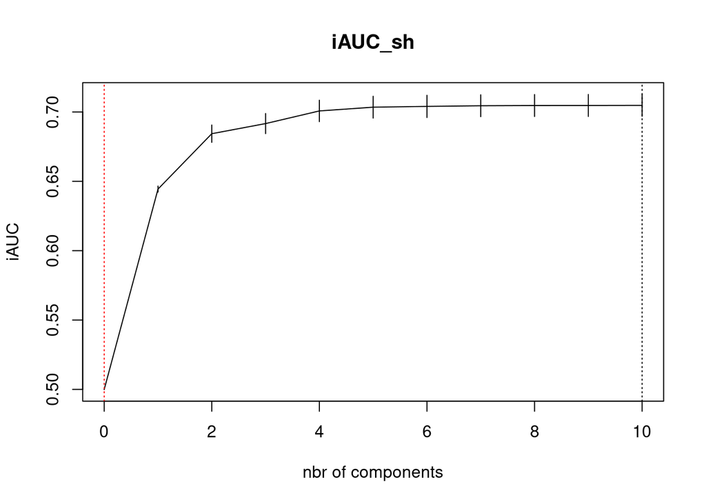

```r
fit <- plsRcox(est_dd[,pre_var], time = est_dd$OS.time, event = est_dd$OS, nt = as.numeric(cv.plsRcox.res[5]))
```

```
## ____************************************************____
## ____Component____ 1 ____
## ____Component____ 2 ____
## ____Component____ 3 ____
## ____Component____ 4 ____
## ____Component____ 5 ____
## ____Component____ 6 ____
## ____Component____ 7 ____
## ____Component____ 8 ____
## ____Component____ 9 ____
## ____Component____ 10 ____
## ____Predicting X without NA neither in X nor in Y____
## ****________________________________________________****
```

```r
rs <- lapply(val_dd_list, function(x){cbind(x[, 1:2], RS = as.numeric(predict(fit,type = "lp", newdata = x[, -c(1, 2)])))})
cc <- data.frame(Cindex = sapply(rs, function(x){as.numeric(summary(coxph(Surv(OS.time,OS) ~ RS, x))$concordance[1])})) %>%
  rownames_to_column('ID')
cc$Model <- paste0('plsRcox')
result <- rbind(result, cc)
```

# 6.superpc

```r
data <- list(x = t(est_dd[, -c(1,2)]), y = est_dd$OS.time, censoring.status = est_dd$OS, featurenames = colnames(est_dd)[-c(1, 2)])
set.seed(seed)
fit <- superpc.train(data = data,type = 'survival', s0.perc = 0.5)
cv.fit <- superpc.cv(fit, data, n.threshold = 20,
                     n.fold = 10,
                     n.components = 3,
                     min.features = 5,
                     max.features = nrow(data$x),
                     compute.fullcv = TRUE,
                     compute.preval = TRUE)
rs <- lapply(val_dd_list, function(w){
  test <- list(x = t(w[,-c(1,2)]), y = w$OS.time, censoring.status = w$OS, featurenames = colnames(w)[-c(1,2)])
  ff <- superpc.predict(fit, data, test, threshold = cv.fit$thresholds[which.max(cv.fit[["scor"]][1,])], n.components = 1)
  rr <- as.numeric(ff$v.pred)
  rr2 <- cbind(w[,1:2], RS = rr)
  return(rr2)
  })
cc <- data.frame(Cindex = sapply(rs,function(x){as.numeric(summary(coxph(Surv(OS.time, OS) ~ RS, x))$concordance[1])})) %>%
  rownames_to_column('ID')
cc$Model <- paste0('SuperPC')
result <- rbind(result, cc)
```

# 7.GBM

```r
set.seed(seed)
fit <- gbm(formula = Surv(OS.time,OS)~., data = est_dd, distribution = 'coxph',
           n.trees = 10000,
           interaction.depth = 3,
           n.minobsinnode = 10,
           shrinkage = 0.001,
           cv.folds = 10, n.cores = 6)

# 找到具有最小交叉验证误差的树数量索引
# find index for number trees with minimum CV error
best <- which.min(fit$cv.error)

set.seed(seed)
fit <- gbm(formula = Surv(OS.time, OS)~., data = est_dd, distribution = 'coxph',
           n.trees = best,
           interaction.depth = 3,
           n.minobsinnode = 10,
           shrinkage = 0.001,
           cv.folds = 10, n.cores = 8)
rs <- lapply(val_dd_list,function(x){cbind(x[,1:2], RS = as.numeric(predict(fit, x, n.trees = best, type = 'link')))})
cc <- data.frame(Cindex = sapply(rs, function(x){as.numeric(summary(coxph(Surv(OS.time, OS) ~ RS, x))$concordance[1])})) %>%
  rownames_to_column('ID')
cc$Model <- paste0('GBM')
result <- rbind(result, cc)
```

# 8.survivalsvm

```r
fit = survivalsvm(Surv(OS.time,OS)~., data = est_dd, gamma.mu = 1)
rs <- lapply(val_dd_list, function(x){cbind(x[,1:2], RS = as.numeric(predict(fit, x)$predicted))})
cc <- data.frame(Cindex = sapply(rs, function(x){as.numeric(summary(coxph(Surv(OS.time, OS) ~ RS, x))$concordance[1])})) %>%
  rownames_to_column('ID')
cc$Model <- paste0('survival - SVM')
result <- rbind(result, cc)
```

# 9.Ridge

```r
x1 <- as.matrix(est_dd[, pre_var])
x2 <- as.matrix(Surv(est_dd$OS.time, est_dd$OS))
set.seed(seed)
fit = glmnet(x1, x2, family = "binomial", alpha = 0, lambda = NULL)
cvfit = cv.glmnet(x1, x2,
                  nfold = 10,
                  family = "binomial",
                  type.measure = "class"
)

rs <- lapply(val_dd_list, function(x){cbind(x[, 1:2], RS = as.numeric(predict(fit, type = 'response', newx = as.matrix(x[, -c(1,2)]), s = cvfit$lambda.min)))})
cc <- data.frame(Cindex = sapply(rs, function(x){as.numeric(summary(coxph(Surv(OS.time,OS) ~ RS, x))$concordance[1])})) %>%
  rownames_to_column('ID')
cc$Model <- paste0('Ridge')
result <- rbind(result, cc)
```

# 10.Lasso

```r
x1 <- as.matrix(est_dd[, pre_var])
x2 <- as.matrix(Surv(est_dd$OS.time, est_dd$OS))
set.seed(seed)
fit = cv.glmnet(x1, x2,
                nfold = 10,
                family = "binomial", alpha = 1,
                type.measure = "class")
rs <- lapply(val_dd_list, function(x){cbind(x[, 1:2], RS = as.numeric(predict(fit, type = 'response', newx = as.matrix(x[, -c(1,2)]), s = fit$lambda.min)))})
cc <- data.frame(Cindex = sapply(rs, function(x){as.numeric(summary(coxph(Surv(OS.time, OS) ~ RS, x))$concordance[1])})) %>%
  rownames_to_column('ID')
cc$Model <- paste0('Lasso')
result <- rbind(result, cc)

## 10.1.Lasso + CoxBoost
x1 <- as.matrix(est_dd[, pre_var])
x2 <- as.matrix(Surv(est_dd$OS.time, est_dd$OS))
set.seed(seed)
fit = cv.glmnet(x1, x2,
                nfold = 10,
                family = "cox", alpha = 1)
fit$lambda.min
```

```
## [1] 0.03305476
```

```r
myCoefs <- coef(fit, s = "lambda.min");
rid <- myCoefs@Dimnames[[1]][which(myCoefs != 0 )]
rid <- rid[-1]
est_dd2 <- est_data[, c('OS.time', 'OS', rid)]
val_dd_list2 <- lapply(val_data_list, function(x){x[, c('OS.time', 'OS', rid)]})
set.seed(seed)
pen <- optimCoxBoostPenalty(est_dd2[, 'OS.time'], est_dd2[, 'OS'], as.matrix(est_dd2[, -c(1,2)]),
                            trace = TRUE, start.penalty = 500, parallel = T)
```

```
## iteration 1 : evaluating penalty 500
```

[output not shown]

```r
cv.res <- cv.CoxBoost(est_dd2[, 'OS.time'], est_dd2[, 'OS'], as.matrix(est_dd2[, -c(1,2)]),
                      maxstepno = 500, K = 10, type = "verweij", penalty = pen$penalty)
fit <- CoxBoost(est_dd2[, 'OS.time'], est_dd2[, 'OS'], as.matrix(est_dd2[, -c(1,2)]),
                stepno = cv.res$optimal.step, penalty = pen$penalty)
rs <- lapply(val_dd_list2, function(x){cbind(x[,1:2], RS = as.numeric(predict(fit, newdata = x[,-c(1,2)], newtime = x[,1], newstatus = x[,2], type = "lp")))})
cc <- data.frame(Cindex=sapply(rs, function(x){as.numeric(summary(coxph(Surv(OS.time, OS) ~ RS, x))$concordance[1])})) %>%
  rownames_to_column('ID')
cc$Model <- paste0('Lasso + CoxBoost')
result <- rbind(result, cc)

## 10.2.Lasso + GBM
x1 <- as.matrix(est_dd[, pre_var])
x2 <- as.matrix(Surv(est_dd$OS.time, est_dd$OS))
set.seed(seed)
fit = cv.glmnet(x1, x2,
                nfold = 10,
                family = "binomial", alpha = 1,
                type.measure = "class")
fit$lambda.min
```

```
## [1] 0.01801446
```

```r
myCoefs <- coef(fit, s = "lambda.min");
rid <- myCoefs@Dimnames[[1]][which(myCoefs != 0 )]
rid <- rid[-1]
est_dd2 <- est_data[,c('OS.time', 'OS', rid)]
val_dd_list2 <- lapply(val_data_list, function(x){x[,c('OS.time', 'OS', rid)]})
set.seed(seed)
fit <- gbm(formula = Surv(OS.time,OS)~., data = est_dd2, distribution = 'coxph',
                         n.trees = 10000,
                         interaction.depth = 3,
                         n.minobsinnode = 10,
                         shrinkage = 0.001,
                         cv.folds = 10, n.cores = 6)

# 找到具有最小交叉验证误差的树数量索引
# find index for number trees with minimum CV error
best <- which.min(fit$cv.error)

set.seed(seed)
fit <- gbm(formula = Surv(OS.time,OS)~., data = est_dd2, distribution = 'coxph',
           n.trees = best,
           interaction.depth = 3,
           n.minobsinnode = 10,
           shrinkage = 0.001,
           cv.folds = 10, n.cores = 8)
rs <- lapply(val_dd_list2, function(x){cbind(x[, 1:2], RS = as.numeric(predict(fit, x, n.trees = best, type = 'link')))})
cc <- data.frame(Cindex = sapply(rs,function(x){as.numeric(summary(coxph(Surv(OS.time, OS) ~ RS, x))$concordance[1])}))%>%
  rownames_to_column('ID')
cc$Model <- paste0('Lasso + ', 'GBM')
result <- rbind(result, cc)

## 10.3.Lasso + plsRcox
x1 <- as.matrix(est_dd[, pre_var])
x2 <- as.matrix(Surv(est_dd$OS.time, est_dd$OS))
set.seed(seed)
fit = cv.glmnet(x1, x2,
                nfold = 10,
                family = "binomial", alpha = 1,
                type.measure = "class")
fit$lambda.min
```

```
## [1] 0.01801446
```

```r
myCoefs <- coef(fit, s = "lambda.min");
rid <- myCoefs@Dimnames[[1]][which(myCoefs != 0 )]
rid <- rid[-1]
est_dd2 <- est_data[,c('OS.time', 'OS', rid)]
val_dd_list2 <- lapply(val_data_list, function(x){x[,c('OS.time', 'OS', rid)]})
set.seed(seed)
cv.plsRcox.res = cv.plsRcox(list(x = est_dd2[, rid], time = est_dd2$OS.time, status = est_dd2$OS), nt = 10, verbose = FALSE)
```

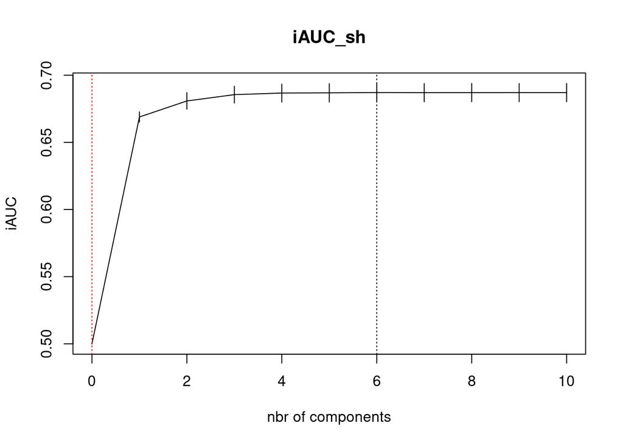

```r
fit <- plsRcox(est_dd2[, rid], time = est_dd2$OS.time, event = est_dd2$OS, nt = as.numeric(cv.plsRcox.res[5]))
```

```
## ____************************************************____
## ____Component____ 1 ____
## ____Component____ 2 ____
## ____Component____ 3 ____
## ____Component____ 4 ____
## ____Component____ 5 ____
## ____Component____ 6 ____
## ____Predicting X without NA neither in X nor in Y____
## ****________________________________________________****
```